# Data structures and Functions

- Part 1
  - Mutable and immutable types
  - List
  - Tuple (and named tuple)
  - Set (+frozen set)
  - Dict
  - File-like objects
- Part 2
  - Functions
  - Arguments
  - Namespaces
  - Scopes (LEGB)
  - Enclosing

### Data

facts representation, terms or instructions in format suitable for processing.

### Data structures

is a data organization, management, and storage format that enables efficient access and modification

#### A mutable object can be changed after it's created, and an immutable object can't.

[figure not shown]

# List

- mutable sequence
- ordered
- homogeneous - typically used to store items of the same type (but can have different types)
- max size of a list depends on system, for example on 64-bit:

  ```
  >>> sys.maxsize // 8
  1152921504606846975 # max number of elements
  ```

- dynamic array under the hood
- array of pointers

[figure not shown]

### Lists may be constructed in several ways:

```python
snake = list('hat') # passing object that can be represented as a sequence of elements (iterable)
simple = ['hat']
noble_programmer = ["Knuth", "Tanenbaum", "bike"]
matrix = [[1, 2], [3, 4]]
hungry_list = []

print(snake, simple, noble_programmer, matrix, hungry_list)
```

```
['h', 'a', 't'] ['hat'] ['Knuth', 'Tanenbaum', 'bike'] [[1, 2], [3, 4]] []
```

```python
import dis

print(dis.dis(lambda: list()))
print(dis.dis(lambda: []))
```

```
  3           0 LOAD_GLOBAL              0 (list)
              2 CALL_FUNCTION            0
              4 RETURN_VALUE
None
  4           0 BUILD_LIST               0
              2 RETURN_VALUE
None
```

## Main methods:

### Add new elements

- **append** and **extend** - add one element or sequence to the end

```python
l = [1, 2, 3]
l.append([4])
l.extend([5, 6])
l
```

```
[1, 2, 3, [4], 5, 6]
```

- past element to specific place **insert**

```python
l = [1, 2, 3]
l.insert(0, 'Null')
print(l, id(l))
l.insert(-1, 'some')
print(l, id(l))
```

```
['Null', 1, 2, 3] 4578294656
['Null', 1, 2, 'some', 3] 4578294656
```

### Alter list

- change sequence:

```python
l = [4, 2, 3]
l[1:2] = [5] * 3
l[0] = 1
l
```

```
[1, 5, 5, 5, 3]
```

### Concatenate lists

```python
l1 = [1, 2]
l2 = [3]
print(id(l1), id(l2))
print(id(l1 + l2))
```

```
139803672921352 139803672915400
139803672920968
```

**Inplace** concatenation

```python
l1 = [1, 2]
l2 = [3]
print(id(l1), id(l2))
l1 += l2 # equivalent to l1.extend(l2)
print(id(l1))
```

```
4578297280 4578297792
4578297280
```

### Remove elements

- remove element or sequence from list -- **del** using index

```python
l = [1, 2, 3]
del l[:2]
print(l)
del l[:]
print(l)
del l
l
```

```
[3]
[]
```

```
---------------------------------------------------------------------------
NameError                                 Traceback (most recent call last)
<ipython-input-148-0ae5c7c8af29> in <module>
      5 print(l)
      6 del l
----> 7 l

NameError: name 'l' is not defined
```

- **pop** to get deleted value

```python
l = [1, 2, 3]
last = l.pop()
first = l.pop(0)
print(first, last, l)
```

```
1 3 [2]
```

- delete first occurrence

```python
kebab = [1, 1, 3, 1]
kebab.remove(1)
kebab
```

```
[1, 3, 1]
```

**list.index(x, [start [, end]])**

returns first occurrence of x (searching from start to end)

```python
l = [1, 2, 3]
l.index(1)
```

```
0
```

```python
l = [1, 2, 3]
l.index(46)
```

[output not shown]

**list.count(x)** Counts elements with value x

```python
l = [1, 1, 1, 2, 3]
l.count(1)
```

```
3
```

```python
l = [1, 1, 1, 2, 3]
l.count(4)
```

```
0
```

### How to reverse list?

```python
# reverse in-place with .reverse()
l = [1, 2, 3]
l.reverse()
l
```

```
[3, 2, 1]
```

```python
# slice returns a new reversed list
l = [1, 2, 3]
lr = l[::-1]
lr
```

```
[3, 2, 1]
```

```python
# reversed(l) returns an iterator
l = [1, 2, 3]
lr = reversed(l)
print(lr)
print(list(lr))
list(lr)
```

```
<list_reverseiterator object at 0x113007be0>
[3, 2, 1]
```

```
[]
```

### How to sort list ?

```python
# in-place
l = [3, 1, 2]
l.sort()
l
```

```
[1, 2, 3]
```

```python
# new list; sorted() works on any iterable
l = [3, 1, 2]
l_sorted = sorted(l)
print(l, l_sorted)
```

```
[3, 1, 2] [1, 2, 3]
```

We can specify order and key for **sorted** **sort**

```python
l = [3, 4, 2, 1]
l.sort(key=lambda x: x % 2, reverse=False)
l
```

```
[4, 2, 3, 1]
```

### List comprehensions

List comprehensions provide a concise way to create lists.

Logically identical to for loop.

A list comprehension consists of brackets containing an expression followed by a for clause, then zero or more for or if clauses.

```python
a = []

for i in range(10):
    a.append(i)

b = [i for i in range(10) if i%2==0]

print(a)
print(b)
```

```
[0, 1, 2, 3, 4, 5, 6, 7, 8, 9]
[0, 2, 4, 6, 8]
```

```python
b = [i for i in range(10) if i%2==0]

c = [i if i % 2 == 1 else 666 for i in range(10)]

print(b)
print(c)
```

```
[0, 2, 4, 6, 8]
[666, 1, 666, 3, 666, 5, 666, 7, 666, 9]
```

```python
# list comprehensions could be nested
[[j for j in range(3)] for i in range(3)]
```

```
[[0, 1, 2], [0, 1, 2], [0, 1, 2]]
```

```python
matrix = [[1, 2, 3], [4, 5], [6, 7, 8, 9]]

print([val for sublist in matrix for val in sublist])
```

```
[1, 2, 3, 4, 5, 6, 7, 8, 9]
```

```python
# functions creating iterators for efficient looping
from itertools import chain

print(list(chain(*matrix)))
```

```
[1, 2, 3, 4, 5, 6, 7, 8, 9]
```

## Slicing

```
a[start:stop]      # items start through stop-1
a[start:]          # items start through the rest of the array
a[:stop]           # items from the beginning through stop-1
a[:]               # a copy of the whole array
a[start:stop:step] # start through not past stop, by step
```

`:stop` the value the is not in the selected slice.

```
a[::-1]    # all items in the array, reversed
a[1::-1]   # the first two items, reversed
a[:-3:-1]  # the last two items, reversed
a[-3::-1]  # everything except the last two items, reversed
```

```
 +---+---+---+---+---+---+
 | P | y | t | h | o | n |
 +---+---+---+---+---+---+
 0   1   2   3   4   5   6
-6  -5  -4  -3  -2  -1
```

slice(stop) slice(start, stop, step)

```python
employee = ['Vasya', 'Pupkin', 'senior', '300k/ns']

NAME = slice(1)
print(type(NAME))
POSITION = slice(1, 3)
SALARY = slice(3, None)

print(employee[NAME])
print(employee[POSITION])
print(SALARY)

NAME
```

```
<class 'slice'>
['Vasya']
['Pupkin', 'senior']
slice(3, None, None)
```

```
slice(None, 1, None)
```

### Now we know:

- how to initialize lists
- lists method
- some of build-in functions
- Slicing

# Tuple

- ordered
- immutable
- hashable
- can contain mutable elements
- heterogeneous (typically)

```python
point = (1, 2)
date = ('may', 22)

same_point = 1, 2
same_date = 'may', 22

not_tuple = (x for x in range(10)) # generator expression, not a tuple
thats_tuple = tuple(x for x in range(10))
print(type(not_tuple), type(thats_tuple))
```

```
<class 'generator'> <class 'tuple'>
```

```python
t1 = 'some',
t2 = ('some',)
print(t1, t2)
```

```
('some',) ('some',)
```

Is almost the same as list. But why we need it?

- Safe from sequence mutating
- Usually faster than list
- Consume fewer space
- Can be dictionary key

```python
lst = [10, 20, 30]
tpl = (10, 20, 30)
print(lst.__sizeof__())
print(tpl.__sizeof__())
```

```
64
48
```

Tuples are compared position by position: the first item of the first tuple is compared to the first item of the second tuple; if they are not equal, this is the result of the comparison, else the second item is considered, then the third and so on.

```python
(1, 2, 3) < (1, 2, 4)
```

```
True
```

```python
(1, 2, 3, 4) < (1, 2, 4)
```

```
True
```

### methods similar to list

```python
a = (1, 2, 3)
b = (4, 5)
print(a + b) # creates a new object
print(a * 3)
print(a.count(2))
print(a.index(2))
```

```
(1, 2, 3, 4, 5)
(1, 2, 3, 1, 2, 3, 1, 2, 3)
1
1
```

```python
tuple(reversed((1, 2, 3)))
```

```
(3, 2, 1)
```

```python
(1, 2, 3)[::-1]
```

```
(3, 2, 1)
```

### enumerate

```python
my_list = ['apple', 'banana', 'grapes', 'pear']


for c, value in enumerate(my_list, 1):
    print(c, value)
```

```
1 apple
2 banana
3 grapes
4 pear
```

Use iteration over object instead of loops with counter. If you need index - use enumerate

```python
# bad
for i in range(len(xs)) :
    x = xs[i]

# better
for x in xs:
    ...

# or
for i, x in enumerate(xs):
    ...
```

```
---------------------------------------------------------------------------
NameError                                 Traceback (most recent call last)
<ipython-input-31-180f2ea2fd03> in <module>
      1 # bad
----> 2 for i in range(len(xs)) :
      3     x = xs[i]
      4
      5 # better

NameError: name 'xs' is not defined
```

### tuple vs list

**list**

- Mutable
- slower
- homogeneous sequence
- Unhashable

**tuple**

- Immutable
- faster
- heterogeneous sequence
- Hashable

### hashable

An object is hashable if it has a hash value which never changes during its lifetime (it needs a **hash**() method), and can be compared to other objects (it needs an **eq**() method). Hashable objects which compare equal must have the same hash value.

Objects which are instances of user-defined classes are hashable by default. They all compare unequal (except with themselves), and their hash value is derived from their id().

Hashability makes an object usable as a dictionary key and a set member, because these data structures use the hash value internally.

Immutable containers are only hashable if their elements are hashable.

```python
a = (1, 2, 3)
c = (1, 2, 3)
a == c
```

```
True
```

```python
a.__hash__() == c.__hash__()
```

```
True
```

```python
id(a) != id(c)
```

```
True
```

## Collections module

This module implements specialized container datatypes providing alternatives to Python’s general purpose built-in containers, dict, list, set, and tuple.

```python
# https://docs.python.org/3/library/collections.html
from collections import deque
foo = deque('abc')
print(foo)
foo.appendleft('z')
print(foo)
bar = foo.popleft()
print(foo, bar)
```

```
deque(['a', 'b', 'c'])
deque(['z', 'a', 'b', 'c'])
deque(['a', 'b', 'c']) z
```

## namedtuple

Named tuples are basically easy-to-create, lightweight alternative to objects. Named tuple instances can be referenced using object-like variable dereferencing or the standard tuple syntax.

```python
from collections import namedtuple

# collections.namedtuple(typename, field_names, *, rename=False, defaults=None, module=None)
car_template = namedtuple('Car' , 'color mileage')
cat_template = namedtuple('Cat' , 'color')

my_car = car_template('red', 3812.4)
my_cat = cat_template("white")
print(my_car + my_cat)
print(type(my_car), type(my_cat))
```

```
('red', 3812.4, 'white')
<class '__main__.Car'> <class '__main__.Cat'>
```

```python
my_car.color
```

```
'red'
```

Can use indexes:

```python
my_car[0]
```

```
'red'
```

### Has a few nice methods

```python
my_car._asdict()
```

```
{'color': 'red', 'mileage': 3812.4}
```

### `_replace()` method creates shallow copy in order to modify some of attributes

```python
my_car._replace(color='blue')
```

```
Car(color='blue', mileage=3812.4)
```

### `_make()` creates new instance from sequence

```python
Car._make(['red', 999])
```

[output not shown]

## Multiple assignment and unpacking

```python
x, y = 10, 20
```

### Same result but different spelling

```python
x, y = 10, 20
x, y = (10, 20)
(x, y) = 10, 20
(x, y) = (10, 20)
```

Can be used with any iterable object

```python
x, y, _ = [10, 20, 30]
print(x, y)
```

```
10 20
```

```python
x, y = 'hi'
x
```

```
'h'
```

Works with any number of objects and even with variables

```python
point = 10, 20, 30
x, y, z = point
print(x, y, z)

(x, y, z) = (z, y, x)
print(x, y, z)
```

```
10 20 30
30 20 10
```

*-operator to unpack the arguments

```python
foo = [1, 2, 3]
print(foo)
print(*foo)
```

```
[1, 2, 3]
1 2 3
```

```python
first, *middle, last = range(4)
middle, type(middle)
```

```
([1, 2], list)
```

```python
first, *_, last = range(4)
first, last
```

```
(0, 3)
```

```python
print(*[1], *[2], 3)
[*range(4), 4]
```

```
1 2 3
```

```
[0, 1, 2, 3, 4]
```

## The same way it works with double asterisk **

New keys will overwrite old ones

```python
dict(**{'x': 1}, y=2, **{'z': 3})
```

```
{'x': 1, 'y': 2, 'z': 3}
```

```python
def foo(a=10, b=20):
    return a, b

print(foo())
bar = {'a': 1, 'b': 2}
print(foo(**bar))
```

```
(10, 20)
(1, 2)
```

## Set

### When to use?

1. remove duplicates
2. Membership testing
3. count intersections, union, difference, symmetric difference

#### NB!

- No indexing and slicing
- No ordered insertion

### How to initialize?

```python
container = {1, 2, 3}
for i in container:
    print(i)
```

```
1
2
3
```

```python
new_set = {i for i in range(5)}
new_set
set()
```

[output not shown]

No literals for empty set:

```python
this_is_not_a_set_sorry = {}
type(this_is_not_a_set_sorry)
```

```
dict
```

But we can create one with elements inside it

```python
brand_new_set = {"youth", "of", "the", "nation"}
print(brand_new_set, id(brand_new_set))
brand_new_set.add("me")
brand_new_set.add("of")
print(brand_new_set, id(brand_new_set))
```

```
{'youth', 'nation', 'of', 'the'} 4546177952
{'youth', 'of', 'nation', 'me', 'the'} 4546177952
```

What will happen if we pass iterable to the constructor?

```python
s = set("privet")
s
```

```
{'e', 'i', 'p', 'r', 't', 'v'}
```

## Set methods

### Returns True or False:

set.isdisjoint(another_set) - True, if set and another_set have no common elements.

set.issubset(another_set) - True, if all set elements are in another_set.

set.issuperset(another_set) - True, if all another_set's elements belong to set.

### Set theory:

set.union(set1, ...) - set's union.

set.intersection(set1, ...) - set's intersection.

set.difference(other, ...) - set of elements, that are not in any of other.

set.symmetric_difference(other) - all elements, that are not in set and in any of other at the same time.

### Mutate set

set.add(elem) - add new element

set.remove(elem) - remove element elem from the set. Raises KeyError if elem is not contained in the set

set.discard(elem) - removes element if is in set

set.pop() - remove and return an arbitrary element from the set. Raises KeyError if the set is empty.

set.clear() - remove all elements

## frozenset - immutable set

we basically remove all methods that can mutate object and call it frozen.

```python
frozen = frozenset("diplome")
frozen.add("water")
```

```
---------------------------------------------------------------------------
AttributeError                            Traceback (most recent call last)
<ipython-input-255-b00608177d90> in <module>
      1 frozen = frozenset("diplome")
----> 2 frozen.add("water")

AttributeError: 'frozenset' object has no attribute 'add'
```

#### Summary

- We know what is the set and how to use it.

# Dictionaries

- set of key: value pairs
- mutable
- indexed by keys, which can be any immutable type; strings and numbers can always be keys
- ordered since python 3.7

## 1. Using literals

```python
dictionary = {}
# or
dictionary = {'West World': 8.4, 'True Detective': 7.6}
dictionary
```

```
{'West World': 8.4, 'True Detective': 7.6}
```

## 2. function dict()

```python
dictionary = dict()
# or
dict_1 = dict([(1, 100), (2, 400)])
dict_2 = dict(a=10, b=20)
print(dict_1, dict_2)
```

```
{1: 100, 2: 400} {'a': 10, 'b': 20}
```

## 3. Method .fromkeys()

```python
dictionary = dict.fromkeys(
    ["Leonardo", "Donatello", "Raphael", "Michelangelo"],
    "ninja"
)
dictionary
```

```
{'Leonardo': 'ninja',
 'Donatello': 'ninja',
 'Raphael': 'ninja',
 'Michelangelo': 'ninja'}
```

## 4. dict-comprehension

```python
dictionary = {number: number**2 for number in range(0, 7, 2)}
dictionary
```

```
{0: 0, 2: 4, 4: 16, 6: 36}
```

## Key could be

- unique object
- hashable

```python
d = {1: 1, 3.14: 1, False: 1, "foo": 1}

d
```

```
{1: 1, 3.14: 1, False: 1, 'foo': 1}
```

## Dict methods

`dict.items()` - returns pair (key, value).

`dict.keys()` - returns key from dict.

`dict.values()` - returns values from dict.

```python
d = {'a': 1, 'b': 1, 'c': 2}
[type(i) for i in d.items()]
```

```
[tuple, tuple, tuple]
```

setdefault() - If key is in the dictionary, return its value. If not, insert key with a value of default and return default. default defaults to None

```python
d = dict(a=1, b=2, c=3)
b_value = d.setdefault('b')
d_value = d.setdefault('d')
e_value = d.setdefault('e', 5)
print(b_value, d_value, e_value, d)
```

```
2 None 5 {'a': 1, 'b': 2, 'c': 3, 'd': None, 'e': 5}
```

get() - Return the value for key if key is in the dictionary, else default. If default is not given, it defaults to None, so that this method never raises a KeyError.

```python
dictionary.get("smth", "other")
```

```
'other'
```

#### getting items with square brackets

```python
print(d['a'])
d['z']
```

```
1
```

```
---------------------------------------------------------------------------
KeyError                                  Traceback (most recent call last)
<ipython-input-54-fe8bbe11e7fd> in <module>
      1 print(d['a'])
----> 2 d['z']

KeyError: 'z'
```

```python
sorted_keys = sorted(d)
print(sorted_keys)
sorted_kv = sorted(d.items()) # sorted by key
dict(sorted_kv)
```

```
['a', 'b', 'c', 'd', 'e']
```

```
{'a': 1, 'b': 2, 'c': 3, 'd': None, 'e': 5}
```

**dict.pop(key[, default])** - remove key and returns value. If no key returns default (by default throws KeyError exception)

**dict.popitem()** - removes and returns pair (key, value) in LIFO order (since 3.7). If dict is empty, throws KeyError.

**dict.update([other])** - updates dict by adding new pairs (key, value). Existing keys are updating. Works in-place

**del dict[key]** - deletes item

**dict.clear()** - deletes all items

### Now we know

- How to create new dictionary
- who can be a key in dict
- Dict methods

### membership testing

```python
foo = [1, 2, 3]
print(2 in foo)
print(77 not in foo)
bar = dict(a=1, b=2, c=3)
print('a' in bar)
print(1 in bar)
print(1 in bar.values())
```

```
True
True
True
False
True
```

## Time complexity

List  
'n' is the number of elements currently in the container. 'k' is either the value of a parameter or the number of elements in the parameter

[figure not shown]

Dict

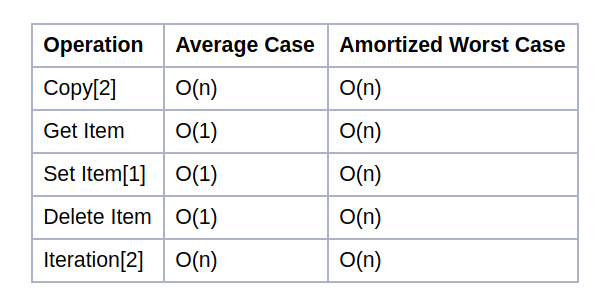

Set - Cpython implementation is very similar to dict

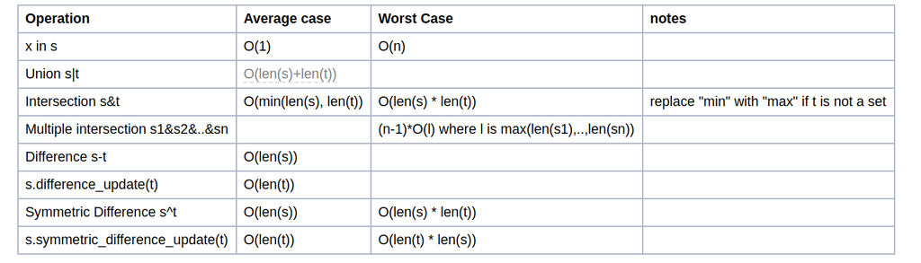

# Files, File-like object and how to use them

### Function open

open() opens file and returns a corresponding file object. Accepts one required argument - path to a file.

```python
open('./data/test.txt')
```

```
<_io.TextIOWrapper name='./data/test.txt' mode='r' encoding='UTF-8'>
```

```
open('/path/to/file', "wb", encoding="utf-8")
```

open have a lot of arguments - a few important:

- **mode** - how to open file:
  - "r", "w", "x", "a", "+"
  - "b", "t".
- for text files:
  - **encoding**
- r opens the file for reading (the default).
- w opens or creates the file for writing, deleting (truncating) its contents first.
- a opens or creates the file for writing, but appends to the end instead of truncating.
- x creates and opens a new file for writing; it cannot open existing files.
- + opens the file for both read and write (always appends to some other flag).
- t works with the file in text mode (the default)
- b works with the file in binary mode

```python
                     | r   r+   w   w+   a   a+   x   x+
-------------------------------------------------------------
allow read           | +   +        +        +        +
allow write          |     +    +   +    +   +    +   +
create new file      |          +   +    +   +    +   +
open existing file   | +   +    +   +    +   +
erase file contents  |          +   +
write after seek     |     +    +   +             +   +
position at start    | +   +    +   +             +   +
position at end      |                   +   +


read - reading from file is allowed
write - writing to file is allowed
create - file is created if it does not exist yet
trunctate - during opening of the file it is made empty (all content of the file is erased)
position at start - after file is opened, initial position is set to the start of the file
position at end - after file is opened, initial position is set to the end of the file
```

Files opened in **binary** mode return contents as bytes objects without any decoding.

In **text** mode the contents of the file are returned as str, the bytes having been first decoded using a platform-dependent encoding or using the specified encoding if given.

```
>>> import locale
>>> locale.getpreferredencoding()
'UTF-8'
```

### Methods to works with files:

#### Reading

Method **read** reads no more than n symbols from file

```python
file_handle = open('./data/test.txt')
file_handle.read(7)
```

```
'line1\nl'
```

**readline** and **readlines** reads line or all lines from file.

```python
file_handle = open('./data/test.txt')
print(len(file_handle.readline()))

file_handle.readlines()
```

```
6
```

```
['line2\n', 'line3\n']
```

#### iterate line by line

```python
for line in file_handle:
    print(line, end='')
```

### Write

```python
file_handle = open("./data/example.txt", "w")
file_handle.write('someinformation')
```

```
15
```

Write sequence of lines to the file. Remember to add new line char `\n`

```python
file_handle.writelines(['spam', 'egg'])
file_handle.close()
open("./data/example.txt", "r").readlines()
```

```
['someinformationspamegg']
```

##### some other methods

```python
file_handle = open("./data/example.txt", "r+")
file_handle.fileno() # file descriptor
```

```
44
```

```python
file_handle.tell() # file object’s current position in bytes
```

```
0
```

```python
file_handle.seek(8)
```

```python
file_handle.write("something unimportant")
file_handle.flush() # Flush the write buffers of the stream
file_handle.close()
```

### Remember to close file! Always!

And to do it in convenient way:

```python
with open("./data/example.txt", "r+") as ouf:
    for line in ouf:
        print(line.strip())

with open("/file1", "r+") as first, open("/file2", "w+") as second:
    ...
```

### What we have learned

- how to open file
- how to work with file
- what is file-like object

## Functions

The keyword `def` introduces a function definition. It must be followed by the function name and the parenthesized list of formal parameters. The statements that form the body of the function start at the next line, and must be indented.

```python
def funny_function():
    """"""
    ...
    return 'to_the_blue_lagoon'
```

```python
funny_function()
```

```
'to_the_blue_lagoon'
```

```python
funny_function
```

```
<function __main__.funny_function()>
```

```python
dir(funny_function) # __dict__
```

```
['__annotations__',
 '__call__',
 '__class__',
 '__closure__',
 '__code__',
 '__defaults__',
 '__delattr__',
 '__dict__',
 '__dir__',
 '__doc__',
 '__eq__',
 '__format__',
 '__ge__',
 '__get__',
 '__getattribute__',
 '__globals__',
 '__gt__',
 '__hash__',
 '__init__',
 '__init_subclass__',
 '__kwdefaults__',
 '__le__',
 '__lt__',
 '__module__',
 '__name__',
 '__ne__',
 '__new__',
 '__qualname__',
 '__reduce__',
 '__reduce_ex__',
 '__repr__',
 '__setattr__',
 '__sizeof__',
 '__str__',
 '__subclasshook__']
```

### Naming constrains

- latin letters
- underscore `_`
- digits 0-9, **but no at the begging!**

```python
def 1foo():
    pass
```

```
  File "<ipython-input-21-735460777140>", line 1
    def 1foo():
        ^
SyntaxError: invalid syntax
```

### Underscores

- leading single underscore - `_foo` - private (but it's just a convention)
- leading double underscore - `__foo` - name mangling; will be replaced with _classname__foo
- leading and trailing double underscore - `__foo__` - system-defined names, informally known as “dunder” names; meant to be used only for names that have a special meaning defined by Python, like the **init**

```python
class MyClass:
    def __init__(self):
        self.__foo = 4
        self._bar = 5

a = MyClass()
print(a.__dict__)
print(a._bar)
print(a.__foo)
```

```
{'_MyClass__foo': 4, '_bar': 5}
5
```

```
---------------------------------------------------------------------------
AttributeError                            Traceback (most recent call last)
<ipython-input-3-f28686344ea2> in <module>
      7 print(a.__dict__)
      8 print(a._bar)
----> 9 print(a.__foo)

AttributeError: 'MyClass' object has no attribute '__foo'
```

**return** could be omitted. Be default returns None

```python
def foo():
    a = 1, 2, 3
    return 1, 2, 3

print(foo())
```

```
(1, 2, 3)
```

```python
print(print(foo()))
```

```
(1, 2, 3)
None
```

Functions could have several **return**

```python
def never_gonna(what):
    if what == 1:
        return 'give you up'
    if what == 2:
        return 'let you down'
    return 'run around and desert you'
    return "You wouldn't get this from any other guy"

print(never_gonna(1))
print(never_gonna(10))
```

```
give you up
run around and desert you
```

For documentation use multi-line string literals

```python
def creep():
    """I wish I was special"""
    return "sorry"
```

How to reveal documentation?

```python
creep.__doc__
```

```
'I wish I was special'
```

```python
help(creep)
```

```
Help on function creep in module __main__:

creep()
    I wish I was special
```

### Arguments

#### Positional arguments

```python
def avg(a, b):
    return (a+b)/2

avg(10, 9)
```

```
9.5
```

#### Keyword arguments

```python
def order_an_ice_cream(scoop, toping="syrup", flavor="chocolate"):
    return "{} scoop(s) with {} and {} toping".format(
        scoop, flavor, toping
    )


print(order_an_ice_cream(10))
print(order_an_ice_cream(3, "nut", "strawberries and bananas"))
print(order_an_ice_cream(scoop=1, toping="KETCHUP??!?!?", flavor="vanilla"))
```

```
10 scoop(s) with chocolate and syrup toping
3 scoop(s) with strawberries and bananas and nut toping
1 scoop(s) with vanilla and KETCHUP??!?!? toping
```

```python
order_an_ice_cream(3, toping="nut", "strawberries and bananas")
```

[output not shown]

### Default arguments initialization

```python
def foo(a, lst=[]):

    lst.append(a)
    return lst


print(foo(1))
print(foo(2))
print(foo(3))
print(foo(1, []))
print(foo(1))
```

```
[1]
[1, 2]
[1, 2, 3]
[1]
[1, 2, 3, 1]
```

Question: when and how many times are default arguments initialized?

`def` statement only gets executed once, when the function is defined

```python
def foo(a, lst=None):
    if lst is None:
        lst = []

    lst.append(a)
    return lst


print(foo(1))
print(foo(2))
print(foo(3))
print(foo(1, ['q']))
print(foo(2))
```

```
[1]
[2]
[3]
['q', 1]
[2]
```

### Packing

```python
def avg(*args):
    return sum(args)/len(args)
```

```python
a = [i for i in range(10)]
avg(*a)
```

```
4.5
```

```python
avg()
```

```
---------------------------------------------------------------------------
ZeroDivisionError                         Traceback (most recent call last)
<ipython-input-39-f5d909301850> in <module>
----> 1 avg()

<ipython-input-37-983fe2e3ee7a> in avg(*args)
      1 def avg(*args):
----> 2     return sum(args)/len(args)

ZeroDivisionError: division by zero
```

```python
def foo_with_args(first, *args):
    print(type(args))
    arguments = (first,) + args
    print(arguments)
    return '; '.join(map(str, arguments))

print(foo_with_args(1, 2, 4))
foo_with_args(1)
```

```
<class 'tuple'>
(1, 2, 4)
1; 2; 4
<class 'tuple'>
(1,)
```

```
'1'
```

```python
def foo_with_args_and_kwargs(first, *args, **kwargs):
    return [first, *args, *((k, v) for k,v in kwargs.items())]


print(*foo_with_args_and_kwargs(1, 10, 100))
print(*foo_with_args_and_kwargs(1, 10, 100, **{'param': True}))

some_dict = {'param': True, 'not_param': False}

print(*foo_with_args_and_kwargs(1, 10, 100, **some_dict))
```

```
1 10 100
1 10 100 ('param', True)
1 10 100 ('param', True) ('not_param', False)
```

### keyword only arguments

To mark parameters as keyword-only, indicating the parameters must be passed by keyword argument, place an * in the arguments list just before the first keyword-only parameter.

```python
def obey_me(param, *, password=None):
    return param, f'password={password}'

print(obey_me(1, password='yeeea'))
obey_me(1, 'noooo')
```

```
(1, 'password=yeeea')
```

```
-----------------------------------------------------
TypeError           Traceback (most recent call last)
<ipython-input-167-9ab327248936> in <module>
      3
      4 print(obey_me(1, password='yeeea'))
----> 5 obey_me(1, 'noooo')

TypeError: obey_me() takes 1 positional argument but 2 were given
```

One more function attribute

```python
obey_me.__kwdefaults__
```

```
{'password': None}
```

Since python 3.8:

Looking at this in a bit more detail, it is possible to mark certain parameters as positional-only. If positional-only, the parameters’ order matters, and the parameters cannot be passed by keyword. Positional-only parameters are placed before a `/` (forward-slash). The `/` is used to logically separate the positional-only parameters from the rest of the parameters. If there is no / in the function definition, there are no positional-only parameters.

Parameters following the `/` may be positional-or-keyword or keyword-only.

```python
def f(pos1, pos2, /, pos_or_kwd, *, kwd1, kwd2):
      -----------    ----------     ----------
        |             |                  |
        |        Positional or keyword   |
        |                                - Keyword only
         -- Positional only
```

```python
import operator


OPERATORS = {
    '+': operator.add,
    '-': operator.sub,
    '*': operator.mul,
    '/': operator.floordiv,
}


def calc_for_two_numbers(x, y, /, operator='+'):
    op = OPERATORS[operator]
    return op(x, y)


print(calc_for_two_numbers(2, 2, '*'))
calc_for_two_numbers(x=2, y=2, operator='*')  # invalid, will raise a TypeError
```

```
4
```

```
---------------------------------------------------------------------------
TypeError                                 Traceback (most recent call last)
<ipython-input-10-3ded213558b3> in <module>
     16
     17 print(calc_for_two_numbers(2, 2, '*'))
---> 18 calc_for_two_numbers(x=2, y=2, operator='*')  # invalid, will raise a TypeError

TypeError: calc_for_two_numbers() got some positional-only arguments passed as keyword arguments: 'x, y'
```

### Callable

A callable is anything that can be called.  
Call function means to call `__call__` method. `add(1, 2)` == `add.__call__(1, 2)`

- user-defined functions
- built-in functions
- methods of built-in objects
- class objects
- methods of class instances
- all objects having a `__call__` method are callable

Defining function like `def funcname(parameters):` you actually creates new object with defined `__call__` method.

### Check if objects is `callable`

```python
print(callable(len), callable(45), callable(callable))
```

```
True False True
```

### Function attributes

- `__doc__` - documentation string `foo.__doc__`
- `__name__` - function's name `foo.__name__ -> foo`
- `__qualname__` - name showing the “path” from a module’s global scope `foo().__qualname__ -> foo.<locals>.bar`
- `__module__` - The name of the module the function was defined in `foo.__module__ -> __main__`
- `__code__` - The code object representing the compiled function body `foo.__code__ -> <code object foo at 0x103c257c0, file "<ipython-input-3-3b449f066ddd>", line 4>`
- `__globals__` - A reference to the dictionary that holds the function’s global variables — the global namespace of the module in which the function was defined `foo.__globals__`

### SCOPES

A namespace is a mapping from names to objects  
There is absolutely no relation between names in different namespaces Namespace ~= dict

[figure not shown]

Namespaces are created at different moments and have different lifetimes.

- namespace containing the built-in names is created when the Python interpreter starts up, and is never deleted
- global namespace for a module is created when the module definition is read in; normally, module namespaces also last until the interpreter quits
- local namespace for a function is created when the function is called, and deleted when the function returns or raises an exception

[figure not shown]

```python
spam = 'spam and eggs'
eggs = spam

print(spam)  # spam and eggs
print(eggs)  # spam and eggs

print(id(spam), id(eggs)) # both names point to the same object
```

```
spam and eggs
spam and eggs
4359780656 4359780656
```

### Enclosing and scope

Enclosing – ability of a function to use variables that doesn't belong to it

```python
def foo():
    foo_variable = "I'm inside foo"
    def bar():
        print(foo_variable)
        print(out_variable)
    bar()

out_variable = "I'm outside"
foo()
```

```
I'm inside foo
I'm outside
```

```python
def foo():
    foo_variable = "I'm inside foo"

print(foo_variable) # raises a NameError exception
```

```
---------------------------------------------------------------------------
NameError                                 Traceback (most recent call last)
<ipython-input-14-471fc12a559b> in <module>
      2     foo_variable = "I'm inside foo"
      3
----> 4 print(foo_variable) # raises a NameError exception

NameError: name 'foo_variable' is not defined
```

### LEGB

A scope is a textual region of a Python program where a namespace is directly accessible - reference to a name attempts to find the name in the namespace.

- scope of a name is the region of a program in which that name has meaning

#### Name lookup is going no more than in 4 scopes: local -> enclosing -> global and built-id

[figure not shown]

**Local**– Names which are assigned within a function. **Enclosing** – Names which are assigned in a closure (function in a function) **Global** – Names which are assigned at the top-level of a module, for example on the top-level of your Python file **Built-in** – Names which are standard Python built-ins, such as open, import, print, return, Exception

[figure not shown]

```python
global_var = 0

def func():
    var = 'variable'

    def print_vars():
        inner_var = 1
        print('inner_var', inner_var) # local
        print('var', var) # enclosing
        print('global_var', global_var) # global
        print('print', print) # print function itself is in built-in

    print_vars()

func()
```

```
inner_var 1
var variable
global_var 0
print <built-in function print>
```

#### To see what is in scope

```python
glabal_var = 0

def func():
    var = 'variable'

    def print_vars(arg):
        inner_var = 1

        print(locals()) # {'arg': 'argument', 'inner_var': 1}
        print(globals()) # {'__name__': '__main__', '__doc__' ..., 'glabal_var' : 0}

    print_vars('argument')

func()
```

Functions is Python can access variables that are not in current scope.

Important to remember: lookup is happens while functions is called.

```python
def f():
    print(i)

for i in range(5):
    f()
```

```
0
1
2
3
4
```

For assignment LEGB is not working

```python
global_var = 0

def foo():
    global_var = global_var + 1

foo()
```

```
---------------------------------------------------------------------------
UnboundLocalError                         Traceback (most recent call last)
<ipython-input-21-9aae0efff233> in <module>
      4     global_var = global_var + 1
      5
----> 6 foo()

<ipython-input-21-9aae0efff233> in foo()
      2
      3 def foo():
----> 4     global_var = global_var + 1
      5
      6 foo()

UnboundLocalError: local variable 'global_var' referenced before assignment
```

Change default behavior with keywords **nonlocal** and **global**

### global

To be able to assign new value to variable that is not in current scope: use **global** operator.

```python
global_var = 0


def foo():
    global global_var
    global_var = global_var + 1


print(global_var)
foo()
print(global_var)
```

```
0
1
```

### nonlocal

```python
def f1():
    a = 1
    b = 2

    def inner():
        nonlocal a
        a = a + b

    inner()
    print('local a is', a)



f1()
```

```
local a is 3
```

### What to remember:

1. Python have 4 scopes: local, enclosing, global, built-in
2. Name lookup is going from local to built-in. Using assignment operator name considered local.
3. This behavior could be changed by using global and nonlocal operators

#### Function annotation

```python
from typing import Iterable, Union
# for python 3.9:
# from collections.abc import Iterable

def are_palindromes(words: Iterable[str], check: str = "all") -> Union[bool, str]:
    if check not in ("all", "any"):
        return f"unknown {check} option; can be 'all' or 'any'"
    palindromes = (word == "".join(reversed(word)) for word in words)
    if check == "any":
        return any(palindromes)
    return all(palindromes)


print(are_palindromes(["madam", "foo"], "any"))

a: None = None
s: str = '123'
```

```
True
```

PEP 484 - Type Hints https://www.python.org/dev/peps/pep-0484/  
PEP 526 - Syntax for Variable Annotations https://www.python.org/dev/peps/pep-0526/

Mypy https://mypy.readthedocs.io/en/stable/index.html

```python
are_palindromes.__annotations__
```

```
{'words': typing.Iterable[str],
 'check': str,
 'return': typing.Union[bool, str]}
```

#### Naming and a few advices:

- Function should do only one thing (logically)
- If it takes time to scroll a function: something goes wrong
- Function name should describe what this function does in a brief manner
- Better long and comprehensive name than short and unclear
- Better use verb to name function

[figure not shown]

xkcd.com/353/